# descriptive_stats_project

Questions for Investigation

This experiment will require the use of a standard deck of playing cards. This is a deck of fifty-two cards divided into four suits (spades, hearts, diamonds, and clubs), each suit containing thirteen cards (Ace, numbers 2-10, and face cards Jack, Queen, and King). You can use either a physical deck of cards for this experiment or you may use a virtual deck of cards such as that found on random.org (http://www.random.org/playing-cards/). For the purposes of this task, assign each card a value: The Ace takes a value of 1, numbered cards take the value printed on the card, and the Jack, Queen, and King each take a value of 10.

1. First, create a histogram depicting the relative frequencies of the card values.
2. Now, we will get samples for a new distribution. Shuffle your deck of cards and draw three cards from it. (You will be sampling from the deck without replacement.) Record the cards that you have drawn and the sum of the three cards’ values. Repeat this sampling procedure a total of at least thirty times.
3. Let’s take a look at the distribution of the card sums. Report descriptive statistics for the samples you have drawn. Include at least two measures of central tendency and two measures of variability.
4. Create a histogram of the sampled card sums you have recorded. Compare its shape to that of the original distribution. How are they different, and can you explain why this is the case?
5. Make some estimates about values you will get on future draws. Within what range will you expect approximately 90% of your draw values to fall? What is the approximate probability that you will get a draw value of at least 20? Make sure you justify how you obtained your values.

# The Rubric:

[^1](https://docs.google.com/document/d/1gVCBsThTXBkUtMiccc4Rj5XT8I9h4ji0bpqTe2uUxRg/pub#)

Criteria

Responses to Project Questions

Question 1: Plotting a histogram of card values

Question 2: Obtain samples from a deck of cards

Question 3: Report descriptive statistics regarding sample taken

Question 4: Plotting a histogram of sampled values

Question 5: Making estimates based on the sampled distribution

Does Not Meet Specifications

Meets Specifications

The histogram does not accurately reflect the card values’ relative frequency distribution or no histogram is provided.

A histogram is provided that accurately reflects the card values’ relative frequency distribution.

Sampled data is not provided, insufficient, or does not reflect the experiment being performed for the project.

At least thirty samples have been performed and the summed values from each sample have been reported in a submitted spreadsheet.

Two measures of central tendency and variability are not reported to describe the sample or are not computed correctly.

At least two measures of central tendency and two measures of variability are accurately reported to summarize and describe the samples taken for Question 2.

The histogram does not accurately reflect sampled values or no histogram is provided. No discussion of the shape of the distribution is provided or comparison is not well-justified.

A histogram accurately reflecting the sampled data is provided. Discussion of the shape is provided, including a comparison to that of the histogram of the original card values.

Estimates made for the prompted questions do not reflect the values obtained from the sample.

Estimates are made for the prompted questions that reflect the samples taken and their distribution.

Lets start with a rough draft of generating a deck of cards. Lets create 4 suites first. Lets create a dictionary of each suite in the deck named *deck*

```python
import matplotlib
%matplotlib inline
from matplotlib.pylab import hist

import numpy as np
from numpy import mean, std, var

from pprint import pprint
```

```python
heart_suite = {"H": [str(i) + 'H' for i in ['A']+range(2,11)+['J', 'Q', 'K']]}

diamond_suite = {"D": [str(i) + 'D' for i in ['A']+range(2,11)+['J', 'Q', 'K']]}

club_suite = {"C": [str(i) + 'C' for i in ['A']+range(2,11)+['J', 'Q', 'K']]}

spade_suite = {"S": [str(i) + 'S' for i in ['A']+range(2,11)+['J', 'Q', 'K']]}

deck = (heart_suite, diamond_suite, club_suite, spade_suite)

deck = {k:{value:num+1 for num, value in enumerate(cardict[k])} for cardict in deck for k in cardict.iterkeys()}

print deck
```

[output not shown]

Lets create a function to pick a pseudo random card out of 4 randomly selected cards from the dictionary of 4 suites.

```python
def random_deck_card(deck):
    selection = ({t[0]:deck[t[0]][t[1]] \
    for t in \
    [(k, random.choice(deck[k].keys())) \
    for k in deck.iterkeys()]})
    res = random.choice(selection.keys())
    return res, selection[res]
```

```python
def sum_shuffled_cards(deck, mini_range, grand_range):
    return [(lambda x: (x, sum([i[1] for i in x])))([random_deck_card(deck) \
    for _ in xrange(mini_range)]) for _ in xrange(grand_range)]
```

```python
#the historgram of this is almost uniform. for instance;
all_cards = reduce(lambda x,y: (x+y), [[i for i in xrange(len(dct))] for dct in deck.itervalues()])

print hist(all_cards)
```

[output not shown]

Lets create a histogram of 30 samples from 3 randomly picked cards each time.

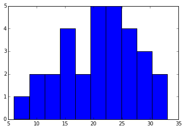

```python
shuffled_cards = sum_shuffled_cards(deck, 3, 30)
print hist(zip(*shuffled_cards)[1])
```

Lets see the shuffled cards

```python
pprint(shuffled_cards)
```

```
[([('H', 8), ('C', 3), ('D', 5)], 16),
 ([('C', 10), ('H', 2), ('H', 11)], 23),
 ([('H', 3), ('S', 2), ('H', 4)], 9),
 ([('C', 10), ('D', 1), ('H', 10)], 21),
 ([('D', 8), ('H', 12), ('H', 12)], 32),
 ([('H', 4), ('S', 2), ('D', 9)], 15),
 ([('D', 1), ('H', 4), ('C', 1)], 6),
 ([('D', 2), ('S', 12), ('D', 12)], 26),
 ([('S', 3), ('D', 2), ('H', 8)], 13),
 ([('H', 10), ('H', 8), ('S', 8)], 26),
 ([('C', 6), ('S', 9), ('C', 3)], 18),
 ([('D', 7), ('C', 10), ('S', 12)], 29),
 ([('S', 1), ('C', 1), ('S', 8)], 10),
 ([('S', 2), ('D', 9), ('D', 11)], 22),
 ([('D', 3), ('C', 6), ('S', 7)], 16),
 ([('D', 11), ('S', 6), ('S', 11)], 28),
 ([('D', 11), ('D', 9), ('C', 6)], 26),
 ([('S', 7), ('D', 10), ('H', 12)], 29),
 ([('H', 8), ('D', 5), ('D', 6)], 19),
 ([('D', 6), ('S', 11), ('H', 6)], 23),
 ([('C', 5), ('D', 9), ('D', 2)], 16),
 ([('C', 11), ('H', 12), ('H', 10)], 33),
 ([('H', 2), ('C', 10), ('S', 8)], 20),
 ([('H', 7), ('S', 13), ('D', 4)], 24),
 ([('S', 11), ('D', 10), ('H', 3)], 24),
 ([('S', 3), ('H', 7), ('C', 3)], 13),
 ([('H', 8), ('C', 2), ('D', 11)], 21),
 ([('C', 13), ('S', 11), ('C', 3)], 27),
 ([('H', 5), ('D', 6), ('C', 9)], 20),
 ([('C', 8), ('S', 11), ('H', 5)], 24)]
```

Lets analyze the sample distribution of samples.

```
Average of list of Sum of all samples: 20.9666666667

(array([ 1.,  2.,  2.,  4.,  2.,  5.,  5.,  4.,  3.,  2.]), array([  6. ,   8.7,  11.4,  14.1,  16.8,  19.5,  22.2,  24.9,  27.6,
        30.3,  33. ]), <a list of 10 Patch objects>)

Unbiased STD DEV of list of sum of all samples std: 45.9643678161

Standard Error of distribution of 30 sample size of 3 samples each: 0.683130051064

Average of list of Sum of all cards: 6.0

(array([ 8.,  4.,  4.,  4.,  4.,  8.,  4.,  4.,  4.,  8.]), array([  0. ,   1.2,   2.4,   3.6,   4.8,   6. ,   7.2,   8.4,   9.6,
        10.8,  12. ]), <a list of 10 Patch objects>)
STD DEV Of all Cards in a suite: 3.74165738677

(array([ 1.,  2.,  2.,  4.,  2.,  5.,  5.,  4.,  3.,  2.]), array([  6. ,   8.7,  11.4,  14.1,  16.8,  19.5,  22.2,  24.9,  27.6,
        30.3,  33. ]), <a list of 10 Patch objects>)
```

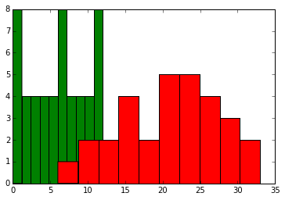

```python
sum_samples = zip(*shuffled_cards)[1]



#standard error
all_cards_std = np.std(all_cards)
se = all_cards_std/np.sqrt(len(sum_samples))

#mean
sum_samples_mean = mean(sum_samples)
print "Average of list of Sum of all samples: {}\n".format(sum_samples_mean)
print hist(sum_samples)
#std deviation
sum_sample_std = sum([(x - sum_samples_mean)**2 for x in sum_samples])/float(len(sum_samples)-1)
print "\nUnbiased STD DEV of list of sum of all samples std: {}\n".format(sum_sample_std)
print "Standard Error of distribution of 30 sample size of 3 samples each: {}\n".format(se)

print "Average of list of Sum of all cards: {}\n".format(mean(all_cards))
print hist(all_cards)
print "STD DEV Of all Cards in a suite: {}\n".format(all_cards_std)


#the histrogram plot - averaging at around 20.9666666667
print hist(zip(*shuffled_cards)[1])
```

Now lets, calculate the SE, Mean and Standard Deviation of this sample of mean plot against the SE, Mean and Standard Deviation of the plot for summed samples. It is shone in the graph below of what happens if we dont sum but take Mean of each times and then take 30 samples of each mean, what will be its mean.

```
(array([ 1.,  2.,  2.,  4.,  2.,  5.,  5.,  4.,  3.,  2.]), array([  2. ,   2.9,   3.8,   4.7,   5.6,   6.5,   7.4,   8.3,   9.2,
        10.1,  11. ]), <a list of 10 Patch objects>)
(array([ 1.,  2.,  2.,  4.,  2.,  5.,  5.,  4.,  3.,  2.]), array([  6. ,   8.7,  11.4,  14.1,  16.8,  19.5,  22.2,  24.9,  27.6,
        30.3,  33. ]), <a list of 10 Patch objects>)

Average of list of Sum of all samples: 20.9666666667


Unbiased STD DEV of list of sum of all samples std: 45.9643678161

Standard Error of distribution of 30 sample size of 3 samples each: 0.683130051064

Average of list of Mean of all samples: 6.98888888889


Unbiased STD DEV of list of sum of all samples std: 5.10715197957

Standard Error of distribution of 30 sample size of 3 samples each: 0.405664622574
```

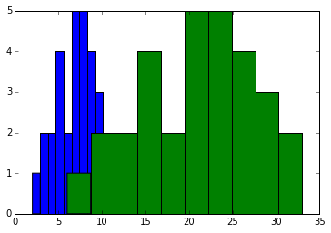

```python
shuffled_cards_sample_mean = [mean([i[1] for i in each_stack[0]]) for each_stack in shuffled_cards]
print hist(shuffled_cards_sample_mean)
print hist(sum_samples)

print "\nAverage of list of Sum of all samples: {}\n".format(sum_samples_mean)
print "\nUnbiased STD DEV of list of sum of all samples std: {}\n".format(sum_sample_std)
print "Standard Error of distribution of 30 sample size of 3 samples each: {}\n".format(se)


#mean and std deviation
mean_shuffled_cards_sample_mean = mean(shuffled_cards_sample_mean)
print "Average of list of Mean of all samples: {}\n".format(mean_shuffled_cards_sample_mean)
shuffled_cards_sample_mean_std = sum([(x - mean_shuffled_cards_sample_mean)**2 for x in shuffled_cards_sample_mean])/float(len(shuffled_cards_sample_mean)-1)
print "\nUnbiased STD DEV of list of sum of all samples std: {}\n".format(shuffled_cards_sample_mean_std)
mean_se = std(shuffled_cards_sample_mean)/np.sqrt(len(shuffled_cards_sample_mean))
print "Standard Error of distribution of 30 sample size of 3 samples each: {}\n".format(mean_se)
```

As we can see from above, the difference between sampling:

1. Means and
2. Sums is the thickness of distribution.

We can note:

which means SE of Mean Samples is lower than of Sum Samples. and Average has come down from ~21 to 6.98888888889 which is alot closer to Average of list of Sum of all cards: 6.0;

However, In the function **sum_shuffled_cards** If we raise the mini_range from 3 to say 30 and grand_range from 30 to 1000, the curve will be even smoother and skinnier with narrower tails meaning, the average will become more defined and precise.